# cv10.R

Marek

2023-04-20

```r
library(latexpdf)
```

# Regresna analyza pokracovanie

zacneme prikladom, ktory bol minule o kapacite a cien diskov. Prelozime regresnu priamku, vysvetlime charakteristiky, ktore sa roluju prikazom summary, funkcia y = a + bx

```r
x <- c(160, 250, 320, 500, 750, 900, 1000, 1500, 2000)
y <- c(789, 800, 851, 874, 1193, 1200, 1335, 1704, 2073)
korelacie <- function(x, y){c('Pearson' = cor(x, y),
                              'Kendall' = cor(x, y, method = 'kendall'),
                              'Spearman' = cor(x, y, method = 'spearman'))}
korelacie(x, y)
```

```
##   Pearson   Kendall  Spearman
## 0.9938807 1.0000000 1.0000000
```

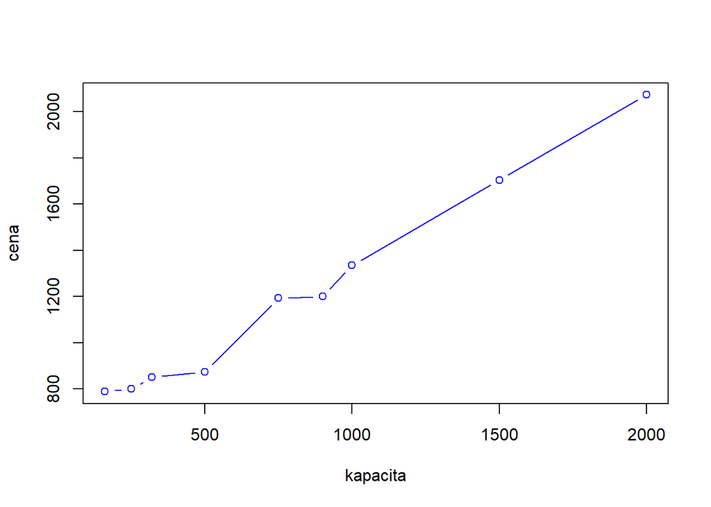

```r
plot(x, y, type = 'b', xlab = 'kapacita', ylab = 'cena', col = 'blue')
```

```r
lm1 <- lm(y~x)
summary(lm1)
```

```
##
## Call:
## lm(formula = y ~ x)
##
## Residuals:
##     Min      1Q  Median      3Q     Max
## -96.912   2.839  10.138  18.341  63.737
##
## Coefficients:
##              Estimate Std. Error t value Pr(>|t|)
## (Intercept) 609.66288   30.45571   20.02 1.94e-07 ***
## x             0.72250    0.03035   23.81 5.87e-08 ***
## ---
## Signif. codes:  0 '***' 0.001 '**' 0.01 '*' 0.05 '.' 0.1 ' ' 1
##
## Residual standard error: 52.67 on 7 degrees of freedom
## Multiple R-squared:  0.9878, Adjusted R-squared:  0.9861
## F-statistic: 566.7 on 1 and 7 DF,  p-value: 5.867e-08
```

```r
#abline(lm1)
```

Prva cast analyza rezidualov, iba charakteristiky polohy. Analyza rezidualov je dolezita v regresii. Regresnu funkciu mozeme prelozit bez obmedzeni (bez podmienok kladenych na data), ale ak chceme testovat a vyhodnotit testy, tak ziadame, aby rezidualy boli normalne rozdelene, s nulovou strednou hodnotou, nekorelovane a s konstantnou disperziou (homoskedasticita) Druha cast: tabulka koeficientov obsahuje odhady parametrov, statistiky, ktore vstupuju do nasledujucich testov a P hodnoty, ktore sluzia na vyhodnotenie testov. Pre prvy riadok (a ostatne) hypoteza je, ze odhadnuty koeficient sa rovna nule $H_)\quad a=0$. Ak koeficient sa rovna nule, nezamietam H0, tak funkcia pri koeficiente do modelu nepatri, nepatri medzi bazove funkcie (tak sa to hovori). Vynechame z bazovych funkcii, prepocitame regresiu, P hodnota < 0.05, zamietame H0 pre prvy aj druhy riadok. Konstanta aj linearny clen patria medzi bazove funkcie Residual standard error - odhad smerodajnej odchylky chyb, cim mensie cislo, tym lepsie, hovori o tom ako blizko alebo ci rozptylene hodnoty daleko od regresnej funkcie R Squared - koeficienty determinacie, cim blizsie k 1, tym lepsie, ak ho prenosbime 100%, tak vieme na kolko % vysvetluje nas model spravanie sa dat. Posledny riadok F statistika pre ANOVA test, nulova hypoteza je, ze Y (zavisla premenna) staci popisat nejakou konstantou, teda nie nasim modelom. V poslednom riadku je aj P hodnota, ak P hodnota je mensia ako 0.05, zamietam hypotezu H0 a teda regresny model je vhodny. Ak mame k dispozicii viac modelov, tak na vyber najlepsieho sluzia hodnoty informacnych kriterii AIC, BIC. Pomocou nich sa vyberie optimalny model, ktory nie je preparametrizovany (penale za velky pocet parametrov) a ani nedoparametrizovany (penale za velku disperziu)

```r
AIC(lm1)
```

```
## [1] 100.6309
```

```r
BIC(lm1)
```

```
## [1] 101.2225
```

porovnajme s modelom y = bx

```r
lm2 <- lm(y~0+x)
AIC(lm1, lm2) #nizsie cislo, lepsi model
```

```
##     df      AIC
## lm1  3 100.6309
## lm2  2 135.2129
```

Dalsie charakteristiky

```r
lm1$coefficients #odhady parametrov
```

```
## (Intercept)           x
## 609.6628811   0.7224978
```

```r
lm1$fitted.values #odhady y pre namerane xi
```

```
##         1         2         3         4         5         6         7         8
##  725.2625  790.2873  840.8622  970.9118 1151.5363 1259.9109 1332.1607 1693.4096
##         9
## 2054.6586
```

```r
lm1$residuals
```

```
##          1          2          3          4          5          6          7
##  63.737464   9.712659  10.137810 -96.911802  41.463738 -59.910938   2.839277
##          8          9
##  10.590357  18.341436
```

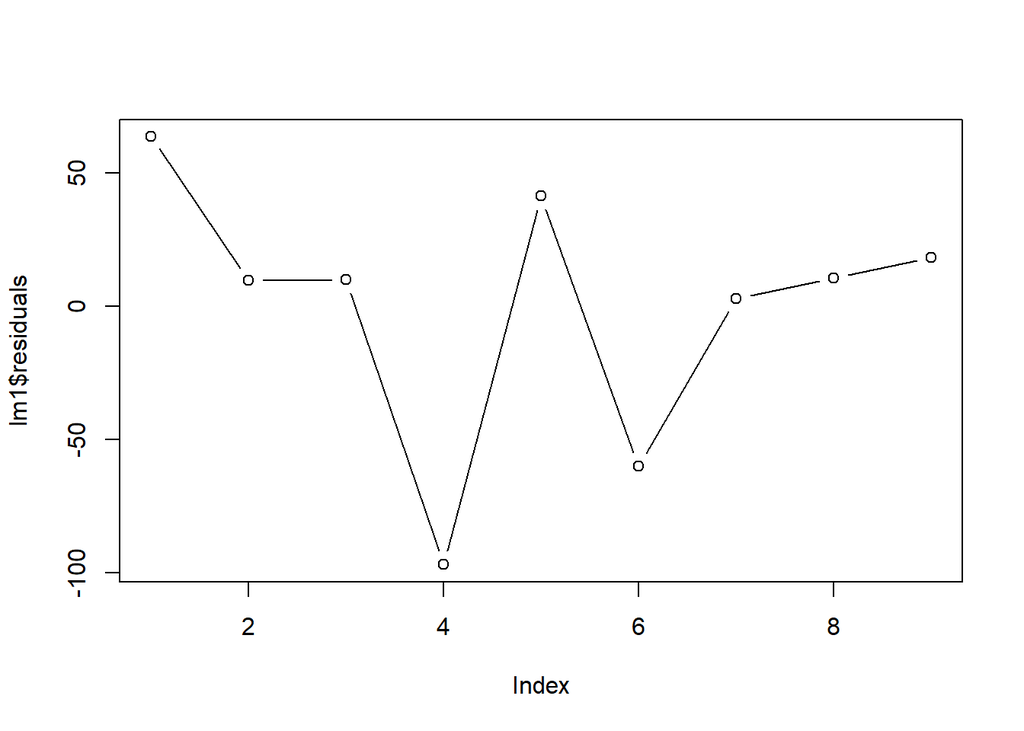

```r
plot(lm1$residuals, type = 'b')
```

```r
##################################
```

Prikald v 10 vzdialenostiach xi sa merala velkost priehybu zatazenia dosky yi, vysledky su dane, prelozte vhodnu regresnu krivku

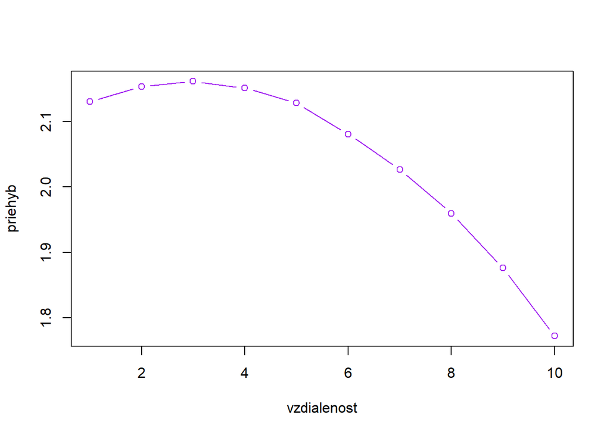

```r
xx <- 1:10
yy <- c(2.1299,2.1532,2.1611,2.151,2.1282,2.0807,
        2.0266,1.9594,1.8759,1.7723 )
plot(xx, yy, type = 'b', xlab = 'vzdialenost', ylab = 'priehyb', col = 'purple')
```

prelozime kvadraticku funkciu, vyhodnotime kvalitu modelu, mozeme vykreslit aj rezidualy

```r
lm3 <- lm(yy~poly(xx, 2))
#lines(lm3$fitted.values, type = 'b', col = 'red')
summary(lm3)
```

```
##
## Call:
## lm(formula = yy ~ poly(xx, 2))
##
## Residuals:
##        Min         1Q     Median         3Q        Max
## -0.0043006 -0.0014714  0.0001463  0.0019730  0.0032679
##
## Coefficients:
##                Estimate Std. Error t value Pr(>|t|)
## (Intercept)   2.0438300  0.0008903 2295.74  < 2e-16 ***
## poly(xx, 2)1 -0.3626960  0.0028153 -128.83 4.48e-13 ***
## poly(xx, 2)2 -0.1756008  0.0028153  -62.37 7.15e-11 ***
## ---
## Signif. codes:  0 '***' 0.001 '**' 0.01 '*' 0.05 '.' 0.1 ' ' 1
##
## Residual standard error: 0.002815 on 7 degrees of freedom
## Multiple R-squared:  0.9997, Adjusted R-squared:  0.9996
## F-statistic: 1.024e+04 on 2 and 7 DF,  p-value: 7.363e-13
```

Kazda z bazovych funkcii patri do mnoziny bazovych funkcii, zamietame hypotezu, ze koeficienty pri funkciach su nulove, odhad smerodajnej odchylky je minimalny, koeficienty determinacie su skoro jedna - kvalitny model. ANOVA test o vhodnosti modelu ako celku, zamietame hypotezu, ze model nema zmysel Vykreslime rezidualy

```r
lm3$residuals
```

```
##             1             2             3             4             5
## -0.0019172727  0.0001778788  0.0021571212  0.0014204545  0.0032678788
##             6             7             8             9            10
## -0.0043006061 -0.0031850000  0.0001146970  0.0023984848 -0.0001336364
```

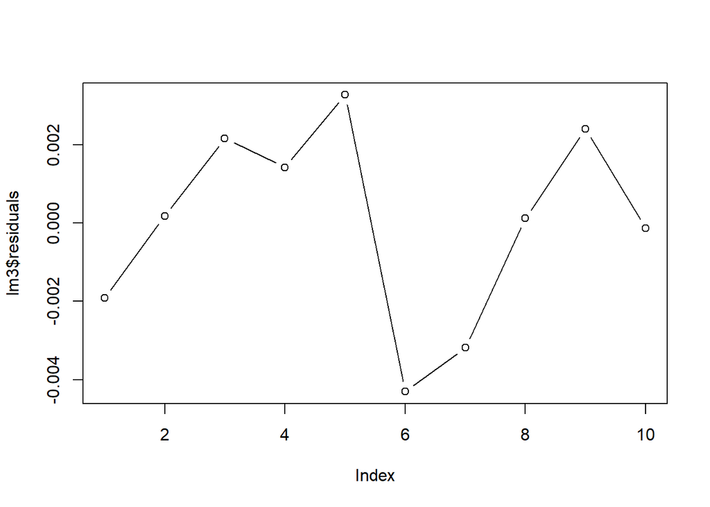

```r
plot(lm3$residuals, type = 'b')
```

```r
library(randtests)
turning.point.test(lm3$residuals)
```

```
##
##  Turning Point Test
##
## data:  lm3$residuals
## statistic = -0.27629, n = 10, p-value = 0.7823
## alternative hypothesis: non randomness
```

```r
##############################################
```

Transformacia na linearnu regresiu Po jednoduchej transformacii mozno pouzit metody linearnej regresie, najst odhady parametrov, spatne transformovat. Priklad barometricky tlak p (v Pascaloch) zavisi od nadmorskej vysky h (m). $y=ae^{bx}$. Namerali sme 6 hodnot tlaku v roznych nadmorskych vyskach. Prelozte danu regresnu krivku.

```r
h <- c(0,270,840,1452,2116,3203)
p <- c(100000,96974,90263,83553,76842,66842)

korelacie(h, p)
```

```
##    Pearson    Kendall   Spearman
## -0.9986763 -1.0000000 -1.0000000
```

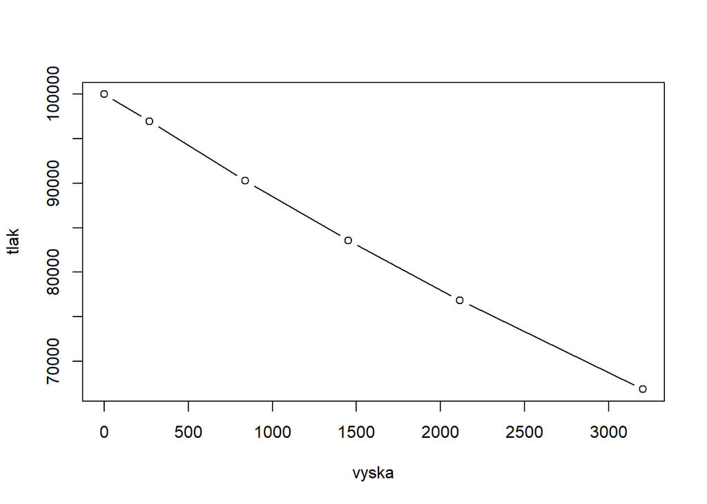

```r
plot(h, p, type = 'b', xlab = 'vyska', ylab = 'tlak')
```

regresia po transformacii dat

```r
lm4 <- lm(log(p)~h)
summary(lm4)
```

```
##
## Call:
## lm(formula = log(p) ~ h)
##
## Residuals:
##          1          2          3          4          5          6
## -0.0024287  0.0008874  0.0010415  0.0009600  0.0009517 -0.0014119
##
## Coefficients:
##               Estimate Std. Error t value Pr(>|t|)
## (Intercept)  1.152e+01  1.082e-03 10643.5 4.68e-16 ***
## h           -1.261e-04  6.313e-07  -199.7 3.77e-09 ***
## ---
## Signif. codes:  0 '***' 0.001 '**' 0.01 '*' 0.05 '.' 0.1 ' ' 1
##
## Residual standard error: 0.001702 on 4 degrees of freedom
## Multiple R-squared:  0.9999, Adjusted R-squared:  0.9999
## F-statistic: 3.989e+04 on 1 and 4 DF,  p-value: 3.77e-09
```

Spatna transformacia pre parametre

```r
a <- exp(lm4$coefficients[1])
a
```

```
## (Intercept)
##    100243.2
```

```r
b <- lm4$coefficients[2]
b
```

```
##             h
## -0.0001260866
```

```r
pp <- a * exp(b*h)
pp
```

```
## [1] 100243.17  96887.99  90169.04  83472.83  76768.90  66936.44
```

```r
#lines(h, pp, type = 'b', col = 'red')
#########################################
```

Regresna analyza s viac ako jednou nezavislou premennou Vysvetlujucich premennych moze byt viac Pokusime sa namodelovat umrtia zz v prvej polovici decembra 52 v Londyne pomocou dvoch premennych xx, yy znecistenie vzduchu

```r
zz <- c(112,140,143,120,196,294,513,518,430,274,
        255,236,256,222,213)
xx <- c(0.3,0.49,0.61,0.49,2.64,3.45,4.46,4.46,1.22,
        1.22,0.32,0.29,0.5,0.32,0.32)
yy <- c(0.09,0.16,0.22,0.14,0.75,0.86,1.34,1.34,0.47,0.47,
        0.22,0.23,0.26,0.16,0.16)
```

najprv spojnicove grafy

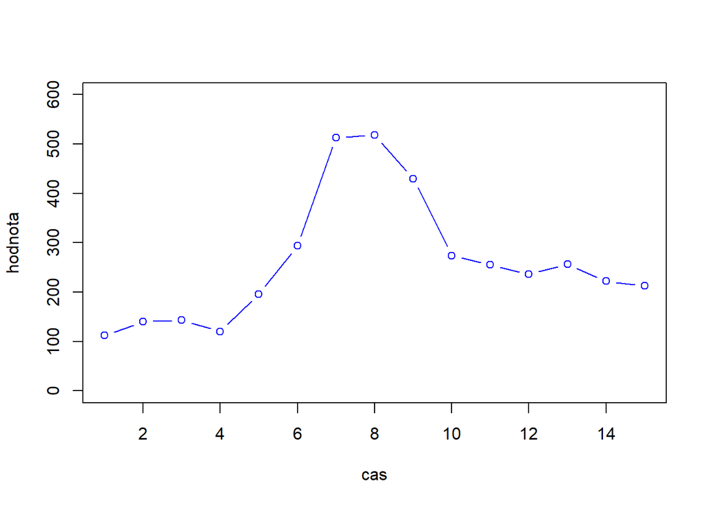

```r
plot(zz, type = 'b', xlab = 'cas', ylab = 'hodnota', col = 'blue',
     ylim = c(0, 600))
```

```r
#lines(xx*100, type = 'b', col = 'red')
#lines(yy*100, type = 'b', col = 'green')
lm5 <- lm(zz~xx+yy)
summary(lm5)
```

```
##
## Call:
## lm(formula = zz ~ xx + yy)
##
## Residuals:
##      Min       1Q   Median       3Q      Max
## -100.717  -20.689   -3.298   15.148  114.931
##
## Coefficients:
##             Estimate Std. Error t value Pr(>|t|)
## (Intercept)    89.51      25.08   3.569 0.003858 **
## xx           -220.32      58.14  -3.789 0.002579 **
## yy           1051.82     212.60   4.947 0.000338 ***
## ---
## Signif. codes:  0 '***' 0.001 '**' 0.01 '*' 0.05 '.' 0.1 ' ' 1
##
## Residual standard error: 52.96 on 12 degrees of freedom
## Multiple R-squared:  0.859,  Adjusted R-squared:  0.8355
## F-statistic: 36.57 on 2 and 12 DF,  p-value: 7.844e-06
```

Nezavislych premennych moze byt viac a mame vybrat len tie, ktore naozaj vysvetluju zavislu premennu, navyse sa nezavisle mozu aj ovplyvnovat (kolinearita, setrit). Zakladny postup na vyukovych datach z kniznice datarium, marketing, su to vydaje na reklamu v mediach youtube, facebook, newspaper a k tomu objem predaja sales

```r
library(datarium)
head(marketing)
```

```
##   youtube facebook newspaper sales
## 1  276.12    45.36     83.04 26.52
## 2   53.40    47.16     54.12 12.48
## 3   20.64    55.08     83.16 11.16
## 4  181.80    49.56     70.20 22.20
## 5  216.96    12.96     70.08 15.48
## 6   10.44    58.68     90.00  8.64
```

Najprv grafy, aby sme odhalili strukturu dat, teraz nas zaujimaju iba dvojice sales+ vzdy kazda nezavisla

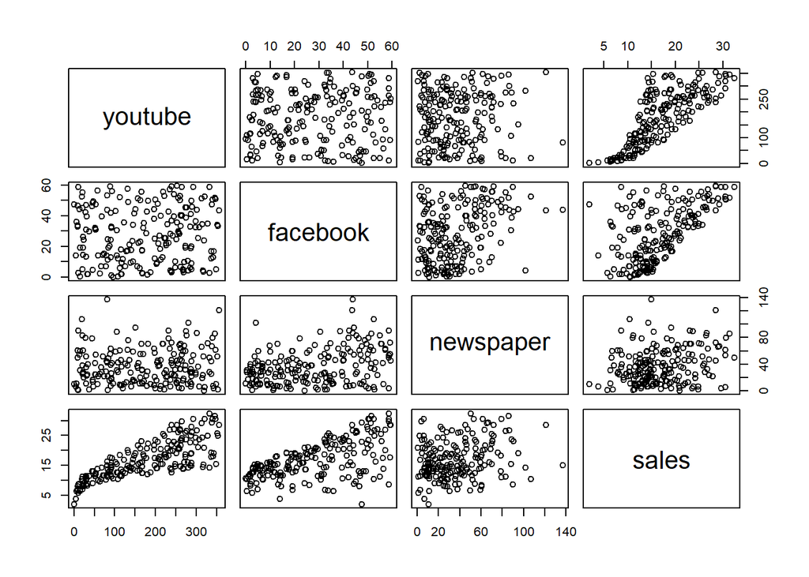

```r
pairs(marketing)
```

korelacie a grafy

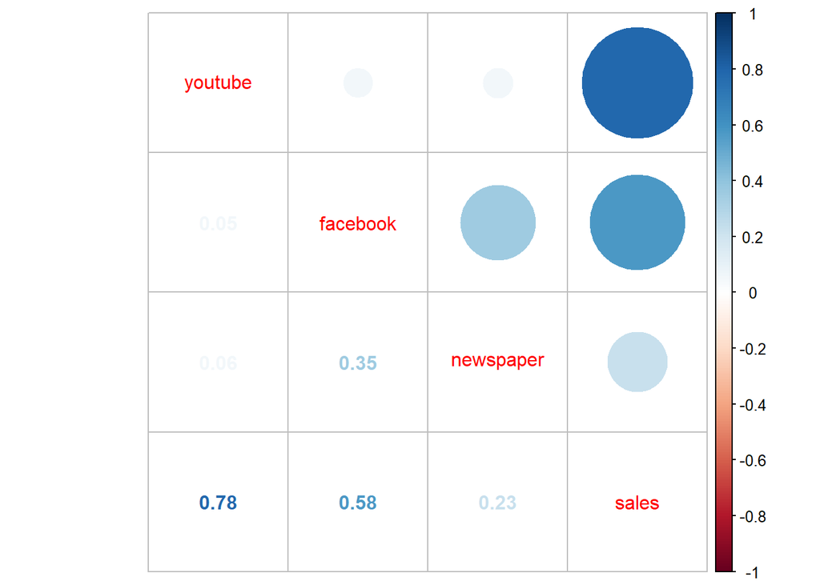

```r
library('corrplot')
k <- cor(marketing)
corrplot.mixed(k)
```

regresna funkcia, vyhodnotenie kvality

```r
lm6 <- lm(sales~., data=marketing)
summary(lm6)
```

```
##
## Call:
## lm(formula = sales ~ ., data = marketing)
##
## Residuals:
##      Min       1Q   Median       3Q      Max
## -10.5932  -1.0690   0.2902   1.4272   3.3951
##
## Coefficients:
##              Estimate Std. Error t value Pr(>|t|)
## (Intercept)  3.526667   0.374290   9.422   <2e-16 ***
## youtube      0.045765   0.001395  32.809   <2e-16 ***
## facebook     0.188530   0.008611  21.893   <2e-16 ***
## newspaper   -0.001037   0.005871  -0.177     0.86
## ---
## Signif. codes:  0 '***' 0.001 '**' 0.01 '*' 0.05 '.' 0.1 ' ' 1
##
## Residual standard error: 2.023 on 196 degrees of freedom
## Multiple R-squared:  0.8972, Adjusted R-squared:  0.8956
## F-statistic: 570.3 on 3 and 196 DF,  p-value: < 2.2e-16
```

Vidime, ze premennu newspaper mozno vylucit z mnoziny bazovych premennych, prepocitame regresiu

```r
lm7 <- lm(sales~youtube + facebook, data = marketing)
summary(lm7)
```

```
##
## Call:
## lm(formula = sales ~ youtube + facebook, data = marketing)
##
## Residuals:
##      Min       1Q   Median       3Q      Max
## -10.5572  -1.0502   0.2906   1.4049   3.3994
##
## Coefficients:
##             Estimate Std. Error t value Pr(>|t|)
## (Intercept)  3.50532    0.35339   9.919   <2e-16 ***
## youtube      0.04575    0.00139  32.909   <2e-16 ***
## facebook     0.18799    0.00804  23.382   <2e-16 ***
## ---
## Signif. codes:  0 '***' 0.001 '**' 0.01 '*' 0.05 '.' 0.1 ' ' 1
##
## Residual standard error: 2.018 on 197 degrees of freedom
## Multiple R-squared:  0.8972, Adjusted R-squared:  0.8962
## F-statistic: 859.6 on 2 and 197 DF,  p-value: < 2.2e-16
```

```r
AIC(lm6, lm7)
```

```
##     df      AIC
## lm6  5 855.2909
## lm7  4 853.3227
```

Kedze nezavislych premennych moze byt viac a nie vsetky patria do regresie, preto je vhodne pouzit prikaz standardneho balika step, predtym regresia pre vsetky premenne

```r
step(lm6)
```

```
## Start:  AIC=285.72
## sales ~ youtube + facebook + newspaper
##
##             Df Sum of Sq    RSS    AIC
## - newspaper  1       0.1  802.0 283.75
## <none>                    801.8 285.72
## - facebook   1    1960.9 2762.7 531.13
## - youtube    1    4403.5 5205.4 657.83
##
## Step:  AIC=283.75
## sales ~ youtube + facebook
##
##            Df Sum of Sq    RSS    AIC
## <none>                   802.0 283.75
## - facebook  1    2225.7 3027.6 547.44
## - youtube   1    4408.7 5210.6 656.03
```

```
##
## Call:
## lm(formula = sales ~ youtube + facebook, data = marketing)
##
## Coefficients:
## (Intercept)      youtube     facebook
##     3.50532      0.04575      0.18799
```

este mame k dispozicii aj napr. kniznicu leaps

```r
library(leaps)
vyber <- regsubsets(sales~., marketing)
summary(vyber)
```

```
## Subset selection object
## Call: regsubsets.formula(sales ~ ., marketing)
## 3 Variables  (and intercept)
##           Forced in Forced out
## youtube       FALSE      FALSE
## facebook      FALSE      FALSE
## newspaper     FALSE      FALSE
## 1 subsets of each size up to 3
## Selection Algorithm: exhaustive
##          youtube facebook newspaper
## 1  ( 1 ) "*"     " "      " "
## 2  ( 1 ) "*"     "*"      " "
## 3  ( 1 ) "*"     "*"      "*"
```

```r
vyber2 <- regsubsets(sales~., marketing, nbest = 2)
summary(vyber2)$bic
```

```
## [1] -178.6890  -70.1065 -439.0879 -191.7038 -433.8214
```

Najlepsi je opat treti (najmensie cislo v bic), teda youtube + facebook